## Peer Assesment 1 data personal movement using activity monitoring devices

### Data

The data for this assignment can be downloaded from Github repository linked attached

### Loading and preprocessing the data

Show any code that is needed to

1. Load the data
2. Process/transform the data (if necessary) into a format suitable for your analysis

First, a directory is created to keep the data in it, afterwards the data is downloaded and unzipped and saved in the directory. First 5 rows are shown

```r
if(!file.exists("./keepdata")){dir.create("./keepdata")}
URL<-"http://d396qusza40orc.cloudfront.net/repdata%2Fdata%2Factivity.zip"
download.file(URL, destfile="./keepdata/activity.zip", "curl")
unzip("./keepdata/activity.zip", exdir = "./keepdata", overwrite = TRUE)
activity <- read.csv("./keepdata/activity.csv", sep = ",", na.strings = "NA")
head(activity)
```

```
##   steps       date interval
## 1    NA 2012-10-01        0
## 2    NA 2012-10-01        5
## 3    NA 2012-10-01       10
## 4    NA 2012-10-01       15
## 5    NA 2012-10-01       20
## 6    NA 2012-10-01       25
```

### What is mean total number of steps taken per day?

For this part of the assignment, you can ignore the missing values in the dataset. 1. Make a histogram of the total number of steps taken each day 2. Calculate and report the mean and median total number of steps taken per day

Firstly, numbers of steps are summed up by day, removing missing values afterwards a historgram is created

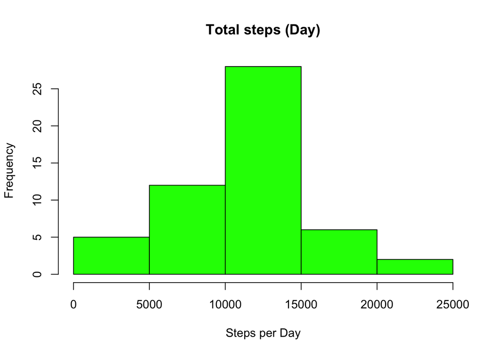

```r
totalSteps_Day <- aggregate( steps ~ date, data = activity, FUN = 'sum',na.rm = TRUE)
hist(totalSteps_Day$steps, main = 'Total steps (Day)',xlab = 'Steps per Day', col = 'green')
```

Secondly, mean and median are reported

```r
mean(totalSteps_Day$steps)
```

```
## [1] 10766.19
```

```r
median(totalSteps_Day$steps)
```

```
## [1] 10765
```

### What is the average daily activity pattern?

1. Make a time series plot (i.e. type = “l”) of the 5-minute interval (x-axis) and the average number of steps taken, averaged across all days (y-axis)
2. Which 5-minute interval, on average across all the days in the dataset, contains the maximum number of steps?

Time series:

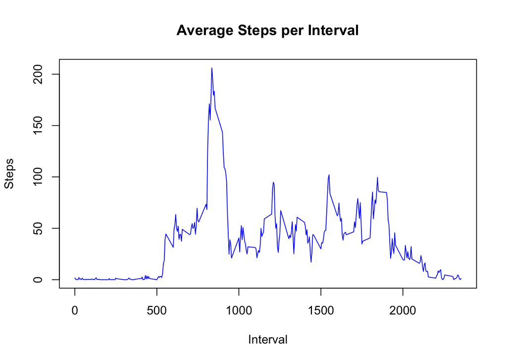

```r
avgSteps <- aggregate( steps ~ interval, data= activity, FUN = 'mean', na.rm=TRUE)
plot(steps ~ interval, data = avgSteps,
     type = 'l',
     main = 'Average Steps per Interval',
     xlab = 'Interval', ylab = 'Steps',
     col = 'blue')
```

Maximum number of steps

```r
avgSteps[ which.max(avgSteps$steps),]$interval
```

```
## [1] 835
```

### Imputing missing values

Calculate and report the total number of missing values in the dataset (i.e. the total number of rows with NAs)

```r
activity_completecases <- activity[complete.cases(activity),]
nNA<-nrow(activity)-nrow(activity_completecases)
nNA
```

```
## [1] 2304
```

Devise a strategy for filling in all of the missing values in the dataset. The strategy does not need to be sophisticated. For example, you could use the mean/median for that day, or the mean for that 5-minute interval, etc.

```r
na_ind        <- which(is.na(activity$steps))
interval      <- as.character(activity[na_ind,3])
average_d_act <- tapply(activity$steps, activity$interval, mean, na.rm=T)
imputed_steps <- average_d_act[interval]
names(imputed_steps) <- na_ind
```

Create a new dataset that is equal to the original dataset but with the missing data filled in.

```r
for (i in na_ind) {
    activity$steps[i] = imputed_steps[as.character(i)]
}
```

Make a histogram of the total number of steps taken each day and Calculate and report the mean and median total number of steps taken per day. Do these values differ from the estimates from the first part of the assignment? What is the impact of imputing missing data on the estimates of the total daily number of steps?

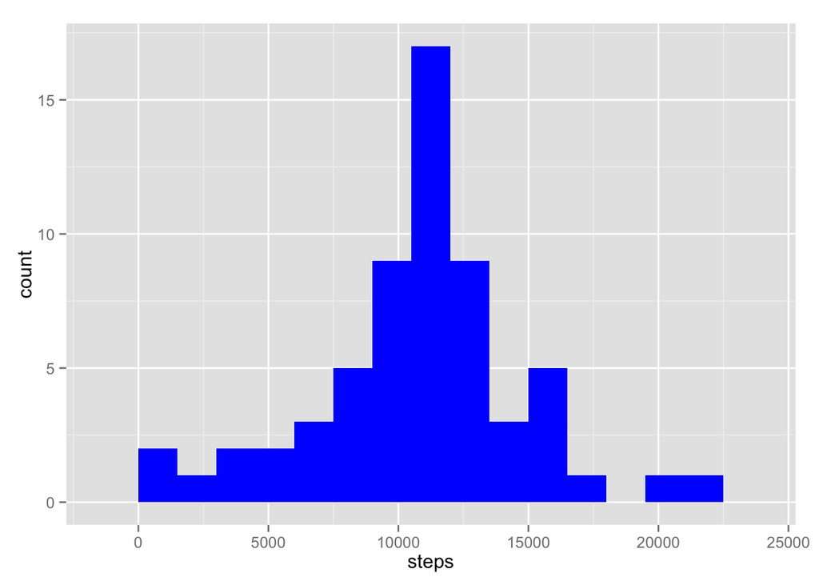

```r
library(ggplot2)
activity.steps_day <- tapply(activity$steps, activity$date, sum)
activity_day       <- data.frame(steps = activity.steps_day)
ggplot( data=activity_day, aes(steps) ) + geom_histogram(binwidth=1500, fill="blue")
```

Calculating the mean total number of steps taken per day

```r
mean(activity.steps_day, na.rm=T)
```

```
## [1] 10766.19
```

Calculating the median total number of steps taken per day:

```r
median(activity.steps_day, na.rm=T)
```

```
## [1] 10766.19
```

The difference of treating the missing data with the mean of the 5 minute interval is that the median moves with one step from 10765 to 10766

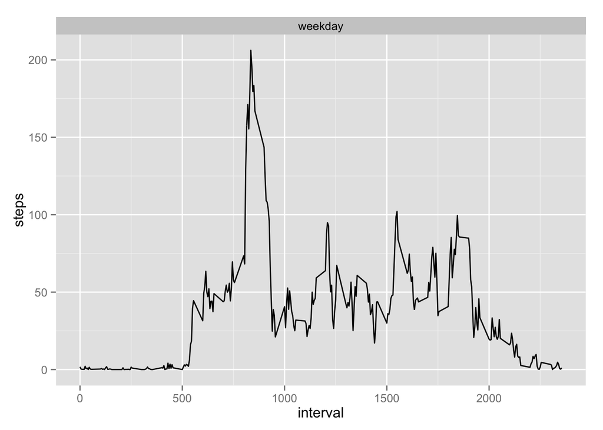

```r
activity$day_type <- ifelse( weekdays(as.Date(activity$date), abbreviate=T) %in% c("Szo", "V"), "weekend", "weekday")

library(reshape2)

average_d_act       <- tapply( activity$steps,list(activity$interval, activity$day_type),mean, na.rm=T)
daily_activity      <- data.frame( interval=as.integer(row.names(average_d_act)), average_d_act)

daily_activity.long <- melt( daily_activity, id.vars="interval",variable.name="day_type", value.name="steps")

ggplot(data=daily_activity.long, aes(interval, steps)) + facet_wrap(~day_type, ncol=1) +geom_line()
```